# index

## Listening to Movies: Film Soundtracks

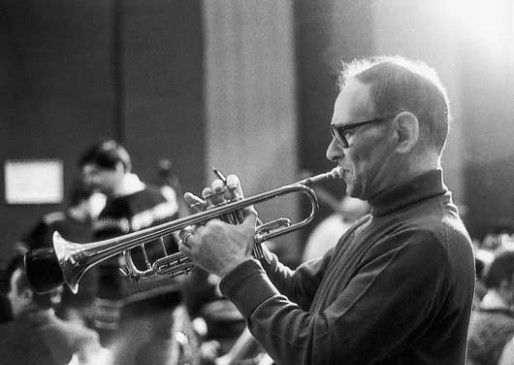

## Description

Since the arrival of sound in cinema in the late 1920s, musical soundtracks have been a key aesthetic element in the history of cinema. This course explores the rich history of cinematic soundtracks, from the pianists that accompanied early silent cinema to the recent popularity of live soundtrack performances at screenings of silent classics such as *The Black Pirate*. Topics include the symphonic music of the “Hollywood Sound”; cartoon music, from *Merrie Melodies* to Walt Disney’s *Fantasia*; jazz and *film noir*; electronic music in 1950s sci-fi movies; Bernard Herrmann’s collaborations with Alfred Hitchcock; the French New Wave soundtracks of Georges Delerue and Michel Legrand; the psychedelic movies of The Beatles and The Monkees; the soundtracks of Ennio Morricone and Lalo Schifrin; the progressive rock soundtracks of the art cinema of Michelangelo Antonioni and Werner Herzog; and the Japanese composer Toru Takemitsu’s collaboration with Akira Kurosawa.

## Reading Assignments

Kathryn Kalinak, [*Film Music: A Very Short Introduction*](https://linker2.worldcat.org/?jHome=http%3A%2F%2F0-search.ebscohost.com.ksclib.keene.edu%2Flogin.aspx%3Fdirect%3Dtrue%26scope%3Dsite%26db%3Dnlebk%26AN%3D311723&linktype=best). Oxford: Oxford University Press, 2010.

This text is available as an e-book via Mason Library.

Other reading assignments will be available for download from Canvas or either individually or collectively as a zip file from the course GitHub repository.

## Viewing Assignments

*Laura* (Otto Preminger, 1944)  
*Fantasia* (Walt Disney, 1940)  
*Forbidden Planet* (Fred M. Wilcox, 1956)  
*Rashomon* (Akira Kurosawa, 1950)  
*The Connection* (Shirley Clarke, 1963)  
*A Fistful of Dollars* (Sergio Leone, 1964)  
*Bullitt* (Peter Yates, 1968)  
*Aguirre, The Wrath of God* (Werner Herzog, 1972)  
*Under the Skin* (Jonathan Glazer, 2013)  
*The Witch* (Robert Eggers, 2015)  
*Dunkirk* (Christopher Nolan, 2017)  
*Annihilation* (Alex Garland, 2018)

## Documentaries

*Lotte Reiniger: Homage to the Inventor of the Silhouette Film* (Katja Raganelli, 1999)  
*Mellodrama: The Mellotron Movie* (Dianna Dilworth, 2004)  
*Music for the Movies: Bernard Herrmann* (Joshua Waletzky, 1992)  
*Music for the Movies: Toru Takemitsu* (Charlotte Zwerin, 1994)  
*Music for the Movies: Georges Delerue* (Jean-Louis Comolli, 1995)  
*Music for the Movies: The Hollywood Sound* (Joshua Waletzky, 1995)  
*Ryuichi Sakamoto: CODA* (Stephen Nomura Schible, 2017)  
*Theremin: An Electronic Odyssey* (Stephen M. Martin, 1993)  
*Deconstructing Dad: The Music, Machines, and Mystery of Raymond Scott* (Stan Warnow, 2010)  
[*Sisters With Transistors*](https://www.kanopy.com/en/product/12168721) (Lisa Rovner, 2020). On Kanopy; requires town library card for access.  
*Ennio: The Maestro* (Giuseppe Tornatore, 2021)

### Online Resources

[The Film Scorer](https://thefilmscorer.com/). Website/blog/podcast devoted specifically to film scoring. Includes reviews, interviews with composers, and analysis.

[DIY Film Composer](https://www.diyfilmcomposer.com/). Practically-oriented blog that includes tutorials on, for example, how to build your own Apprehension Engine.

## Assignments

*Final Research Paper Essay*  
2,000 words. A study of at least three films scored by one composer.

*Synchronicity Project*  
5-10 minute film or video sequence set to an alternative soundtrack of your choice, on the model of the *Wizard of Oz*/*Dark Side of the Moon* model. Shared on Canvas and in class.

*Screening Reports*  
2 in-class presentations of 15-20 minutes on the soundtrack of a film (or other audiovisual text) assigned in any given week. Slides are not required but relevant clips should be selected, screened, and discussed. Presentations in pairs, with students meeting with me during my Thursday office hours to plan their presentation the following week. There is a follow-up essay assignment (see below).

*Screening Report Essay*  
2 short essays approximately 750-1,000 words (3-4 pages double-spaced) in length, based on the in-class presentation.

## Schedule of classes

*Week 1 (Thur 09/01)*

**Introduction: Listening to Film**

Kathryn Kalinak, [*Film Music: A Very Short Introduction*](https://linker2.worldcat.org/?jHome=http%3A%2F%2F0-search.ebscohost.com.ksclib.keene.edu%2Flogin.aspx%3Fdirect%3Dtrue%26scope%3Dsite%26db%3Dnlebk%26AN%3D311723&linktype=best), chs. 1-3 (“What does film music do?,” “How does film music work?,” “Why does film music work?”)

In-class: *Laura*

*Week 2 (Thur 09/08)*

**Overture: The Symphonic Soundtrack**

Kathryn Kalinak, “A History of Film Music I” in [*Film Music: A Very Short Introduction*](https://linker2.worldcat.org/?jHome=http%3A%2F%2F0-search.ebscohost.com.ksclib.keene.edu%2Flogin.aspx%3Fdirect%3Dtrue%26scope%3Dsite%26db%3Dnlebk%26AN%3D311723&linktype=best), ch. 4.

Andrew Ford, [“The Role of Music”](http://dokoissho.sdf.org/ksc-call/soundtracks/pdf/role-music.pdf) (in *The Sound of Pictures*)  
Royal Brown, [“How To Hear A Movie: An Outline”](http://dokoissho.sdf.org/ksc-call/soundtracks/pdf/brown-hear-movie.pdf)  
Stephen Deutsch, [“Editorial”](http://dokoissho.sdf.org/ksc-call/soundtracks/pdf/soundtrack-editorial.pdf) (*The Soundtrack*, vol. 1, no. 1 (2007)

In-class: *Music for the Movies: The Hollywood Sound*

*Week 3 (Thur 09/15)*

**Visual Music: Animation**

Kathryn Kalinak, “A History of Film Music II” in [*Film Music: A Very Short Introduction*](https://linker2.worldcat.org/?jHome=http%3A%2F%2F0-search.ebscohost.com.ksclib.keene.edu%2Flogin.aspx%3Fdirect%3Dtrue%26scope%3Dsite%26db%3Dnlebk%26AN%3D311723&linktype=best), ch. 5.

Charles Granata, [“Disney, Stokowski, and the Genius of *Fantasia*”](http://dokoissho.sdf.org/ksc-call/soundtracks/pdf/stokowski-fantasia.pdf)  
Edward H. Plumb, [“The Future of Fantasound”](http://www.widescreenmuseum.com/sound/fantasound2.htm) (1942)  
Neil Strauss, [“Tunes for Toons: A Cartoon Music Primer”](http://dokoissho.sdf.org/ksc-call/soundtracks/pdf/tunes-toons-intro.pdf)

In-class: *Silly Symphonies*, *Fantasia* (excerpts)

*Week 4 (Thur 09/22)*

**Strange Sounds: Early Electronic**

Kathryn Kalinak, “A History of Film Music III” in [*Film Music: A Very Short Introduction*](https://linker2.worldcat.org/?jHome=http%3A%2F%2F0-search.ebscohost.com.ksclib.keene.edu%2Flogin.aspx%3Fdirect%3Dtrue%26scope%3Dsite%26db%3Dnlebk%26AN%3D311723&linktype=best), ch. 6.

Susan Stone, [“The Barrons: Forgotten Pioneers of Electronic Music”](https://www.npr.org/templates/story/story.php?storyId=4486840) (NPR)  
Ted Greenwald, [“The Self-Destructing Modules Behind Revolutionary 1956 Soundtrack of ‘Forbidden Planet’”](https://www.effectrode.com/knowledge-base/the-self-destructing-modules-behind-revolutionary-1956-soundtrack-of-forbidden-planet/)

[*Bells of Atlantis*](https://www.youtube.com/watch?v=fNodsrQhQ28) (Ian Hugo, 1952)  
*Forbidden Planet* (1956)  
[*Amazing! Exploring the Far Reaches of ‘Forbidden Planet’*](https://drive.google.com/file/d/19U-hq-JlZdRrODsLb4_dqVlUMXjavivr/view?usp=sharing) (2006)

See also: *The Day The Earth Stood Still* (1951); *The Birds* (1963); *Sorcerer* (1977) (Tangerine Dream); *Drive* (2011)

*Week 5 (Thur 09/29)*

**Hitchcock/Herrmann**

Kathryn Kalinak, “Composers and their craft” in [*Film Music: A Very Short Introduction*](https://linker2.worldcat.org/?jHome=http%3A%2F%2F0-search.ebscohost.com.ksclib.keene.edu%2Flogin.aspx%3Fdirect%3Dtrue%26scope%3Dsite%26db%3Dnlebk%26AN%3D311723&linktype=best), ch. 7.

Stephen Deutsch, “[Psycho and the Orchestration of Anxiety](https://canvas.emerson.edu/courses/1622820/files/92106270/download?wrap=1)”

Watch: *Vertigo*, *Psycho*

In-class: *Music for the Movies: Bernard Herrmann*

*Week 6 (Thur 10/06)*

**Cine-Jazz**

Ross Lipman, “[Mingus, Cassavetes, and the Birth of a Jazz Cinema](https://canvas.emerson.edu/courses/1622820/files/92558319/download?wrap=1)”  
Jean-Baptiste Thoret, “[Jazz and Cinema: An Interview With Gilles Mouëllic](http://www.screeningthepast.com/2013/06/jazz-and-cinema-an-interview-with-gilles-mouellic/)”

Watch: *Shadows*, *The Cry of Jazz*  
In-class: *The Connection*

*Week 7 (Thur 10/13)*

**Live Cinema**

[Resource page](https://keene.instructure.com/courses/1933884/pages/the-adventures-of-prince-achmed-lotte-reiniger-1926) on the *Adventures of Prince Achmed* (Lotte Reiniger, 1926)

In-class: Lotte Reiniger, *The Adventures of Prince Achmed* (live soundtrack by Dungen)

*Week 8 (Thur 10/20)*

**Kurosawa/Takemitsu**

Donald Richie, “[Notes on the Film Music of Takemitsu Tōru](https://keene.instructure.com/courses/1933884/files/246510917?wrap=1) [Download Notes on the Film Music of Takemitsu Tōru](https://keene.instructure.com/courses/1933884/files/246510917/download?download_frd=1)”

Lena Pek Hung Lie, “[Toru Takemitsu’s Film Music and Its Corresponding Film Genres](https://keene.instructure.com/courses/1933884/files/245691731?wrap=1) [Download Toru Takemitsu’s Film Music and Its Corresponding Film Genres](https://keene.instructure.com/courses/1933884/files/245691731/download?download_frd=1)”

Watch: *Rashomon*  
In-class: *Music for the Movies: Toru Takemitsu*

**Screening Report B1**

*Week 9 (Thur 10/27)*

**Ennio Morricone**

“[Ennio Morricone](http://dokoissho.sdf.org/ksc-call/soundtracks/pdf/brown-morricone-interview.pdf)” (in Andrew Ford, *The Sound of Pictures*)

In-class: [*A Fistful of Dollars*](https://drive.google.com/file/d/1B1yElphaCn11Msq2J6wv1-CKkKsKfzGO/view?usp=sharing) (Sergio Leone, 1964), opening credits  
[*The Good, The Bad, and the Ugly*](https://drive.google.com/file/d/1w3UabrNalTqA2gSUj7f2UvR7JV8e_tdM/view?usp=sharing) (Sergio Leone, 1967), final duel scene  
[*Le Casse*](https://drive.google.com/file/d/18-6_rqghFln8uFNzwumXKrnjR7AKw6e5/view?usp=sharing) (*The Burglars*) (Henri Verneuil, 1971), opening credits

Watch: *Ennio: The Maestro* (Giuseppe Tornatore, 2021)

**Screening Report B2**

*Week 10 (Thur 11/03)*

**World Music: Popol Vuh**

David Stubbs, “’[Too Much The Darkness’: The Werner Herzog Soundtracks of Popol Vuh](https://thequietus.com/articles/16110-herzog-popol-vuh-overview)” (*The Quietus*, 29 August 2014)

David Stubbs, “[Popol Vuh and Herzog,](https://keene.instructure.com/courses/1933884/files/248065575?wrap=1) [Download Popol Vuh and Herzog,](https://keene.instructure.com/courses/1933884/files/248065575/download?download_frd=1)” in *Future Days: Krautrock and the Birth of a Revolutionary New Music* (London: Faber & Faber, 2014).

Watch: *Aguirre or the Wrath of God*

**Screening Report B3**

*Week 11 (Thur 11/10)*

**The Apprehension Engine**

[Mark Korven website](https://markkorven.com/apprehension-engine.html)

[The Long, Long Awaited Apprehension Engine](http://apprehensionengine.com/PreOrder/)(on Mark Korven’s site)

[DIY Instruments: The Apprehension Engine Part I: Introduction](https://www.diyfilmcomposer.com/diy-instruments-apprehension-engine-part-1/) ([*DIY Film Composer*](https://www.diyfilmcomposer.com/) website, 15 October 2018)

Watch: *The Witch*

**Screening Report B4**

*Week 12 (Thur 11/17)*

**Alien Sounds: Micah Levi**

Ned Beauman, [“Mica Levi’s Intensely Unconventional Film Scores”](https://www.newyorker.com/culture/persons-of-interest/mica-levis-anti-musical-soundtracks) (*New Yorker*, 23 Feb 2017)

Watch: *Under The Skin*  
See also: *Jackie*

NO CLASS (Thanksgiving Week)

*Week 14 (Thur 12/01)*

**Shepherd Tones: Hans Zimmer**

“[How Hans Zimmer Creates Sound Worlds](https://drive.google.com/file/d/1SA5hUx6XaSRGHasYygnAPYGjFvF315je/view?usp=sharing)”  
“[Hans Zimmer Revealed](http://www.hans-zimmer.com/index.php?rub=disco&id=1314)” (2014)  
[Hans Zimmer Spitfire Audio page](https://www.spitfireaudio.com/shop/artists/hans-zimmer/) (digital sample libraries of Hans Zimmer’s film music)  
[Inside Hans Zimmer’s Studio](https://composer.spitfireaudio.com/en/articles/inside-hans-zimmers-studio) (Spitfire Audio)  
Christopher Hauerin, [“The Sound Illusion That Makes *Dunkirk* So Intense”](https://www.vox.com/videos/2017/7/26/16033868/dunkirk-soundtrack-shepard-tone) (*Vox*)

Watch: *Dunkirk* (Christopher Nolan, 2017)

See also: *Inception*; (2010); *Interstellar* (2014)

*Week 15 (Thur 12/08)*

**In-Class: Synchronicity Projects**

**Deadline: Synchronicity Project**

12/09 Classes end

Reading Day (Mon 12/12) Exam period (Tues-Fri 12/13-16)

12/13 **Deadline: Final Research Paper**

## Online Sources

[*The Soundtrack*](https://www.intellectbooks.com/the-soundtrack) (academic journal)  
[Art of the Title](https://www.artofthetitle.com/features/) (web portal about title sequences)

Chris Willman, [“Quentin Tarantino’s ‘Once Upon A Time… In Hollywood’: Deconstructing the Soundtrack”](https://variety.com/2019/music/news/quentin-tarantino-music-supervisor-mary-ramos-once-upon-a-time-in-hollywood-1203281034/?fbclid=IwAR3aIzi3Xd1ejRubTOCeaW9gmTzFa90jkNwfita9qNm1o_4O4uDblGNmUag)

## Select Bibliography

Bridges, Rose (2017). *Yōko Kanno’s ‘Cowboy Bebop’ Soundtrack*. New York: Bloomsbury Academic.

Brophy (2004), Philip. *100 Modern Soundtracks*. London: British Film Institute.

Buhler, James, Caryl Finn, and David Neumeyer (2000). *Music and Cinema*, Hanover, NH: University Press of New England.

Buhler, James, and Hannah Lewis (2020). [*Voicing the Cinema : Film music and the Integrated Soundtrack*](https://linker2.worldcat.org/?jHome=http%3A%2F%2F0-search.ebscohost.com.ksclib.keene.edu%2Flogin.aspx%3Fdirect%3Dtrue%26scope%3Dsite%26db%3Dnlebk%26AN%3D2334639&linktype=best). Urbana: University of Illinois Press.

Chion, Michel (2017). [*Audio-Vision: Sound on Screen*](http://0-search.ebscohost.com.ksclib.keene.edu/login.aspx%3fdirect%3dtrue%26db%3dnlebk%26AN%3d2026762%26site%3dehost-live%26scope%3dsite%26ebv%3DEB%26ppid%3Dpp_171). Second English edition. New York: Columbia University Press [first published 1990].

Culhane, John (1983). *Walt Disney’s Fantasia*. New York: Abradale Press/Harry N. Abrams, Inc.

Deutsch, Stephen (2007). “[Editorial](http://dokoissho.sdf.org/ksc-call/soundtracks/pdf/soundtrack-editorial.pdf).” (*The Soundtrack*, vol. 1, no. 1.

Ford, Andrew (2009). *The Sound of Pictures: Listening to the Movies*. Cullingwood, Victoria: Black, Inc.

Gabbard, Krin (1996). *Jammin’ at the Margins: Jazz and the American Cinema*. Chicago: Chicago University Press.

Goldmark, Daniel, and Yuval Taylor, eds. (2002). *The Cartoon Music Book*. Foreword by Leonard Maltin. Chicago: A Cappella Books.  
—, Lawrence Kramer, and Richard D. Leppert, eds. (2007). *Beyond the Soundtrack: Representing Music in Cinema*. Berkeley: University of California Press.

Greene, Liz, and Danijela Kulezic-Wilson, eds. (2016). [*The Palgrave Handbook of Sound Design and Music in Screen Media : Integrated Soundtracks*](https://linker2.worldcat.org/?jHome=http%3A%2F%2F0-search.ebscohost.com.ksclib.keene.edu%2Flogin.aspx%3Fdirect%3Dtrue%26scope%3Dsite%26db%3Dnlebk%26AN%3D1231407&linktype=best). London: Palgrave Macmillan.

Harper, Graeme, Ruth Doughty, and Jochen Eisentraut, eds. (2009). *Sound and Music in Film and Visual Media*. New York: Bloomsbury Academic.

Hill, Andy (2017). *Scoring the Screen: The Secret Langauge of Film Music*. Music Pro Guides. Milwaukee: Hal Leonard Books.

Kalinak, Kathryn (2010). [*Film Music: A Very Short Introduction*](https://linker2.worldcat.org/?jHome=http%3A%2F%2F0-search.ebscohost.com.ksclib.keene.edu%2Flogin.aspx%3Fdirect%3Dtrue%26scope%3Dsite%26db%3Dnlebk%26AN%3D311723&linktype=best). Oxford: Oxford University Press.

Neumeyer, David, ed. (2014). [*The Oxford Handbook of Film Music Studies*](https://linker2.worldcat.org/?jHome=http%3A%2F%2F0-search.ebscohost.com.ksclib.keene.edu%2Flogin.aspx%3Fdirect%3Dtrue%26scope%3Dsite%26db%3Dnlebk%26AN%3D826679&linktype=best). Oxford and New York: Oxford University Press.

Philips, Winifred (2017). *A Composer’s Guide to Game Music*. Cambridge, MA: MIT Press.

Platte, Nathan (2011). “Music for *Spellbound* (1945): A Contested Collaboration.” *Journal of Musicology*, vol. 48, no. 4: 418-63.

Schartmann, Andrew (2015). *Koji Kondo’s Super Mario Bros. Soundtrack*. New York: Bloomsbury Academic.

## Policies & Protocol

**Attendance** Since this class meets only weekly, attendance is particularly important. Students are allowed one absence per semester. Two absences will lower your final grade half a letter grade. Three absences will lower your grade a whole letter grade. Any more than **three absences**, regardless of the reason, and students will have to withdraw from the course (in accordance with Keene State College student handbook). Come and talk to me if you have any problem in attending the class.

Keene State policy: A student who misses more than 3 weeks in the first 10 weeks of the semester (regardless of the reason, including excused absences and emergencies) must withdraw from the course. The student must follow the regular withdrawal procedure. The complete KSC attendance policy can be viewed at http://www.keene.edu/registrar/policy/policy.cfm#6

## Readings & assignments

Readings assigned for each week should be completed **prior to** the class meeting. Assignments are due at the beginning of the class unless stated otherwise. **Please do not email submissions.**

## Discussion & participation

Class discussion (i.e. your participation) is one of the most essential parts of this class. Please come to class fully prepared—both intellectually and physically. Also keep in mind that we always need to work together in order to create a productive and inspiring academic environment by being polite and respectful toward other students’ comments and ideas. In order to ensure your full participation and engagement in class, the use of laptops and/or mobile devices during lectures, discussion, and screenings is not permitted.

## Academic honesty

We understand and agree that we are participating in higher education. We respect this process and will act as mature and responsible individuals in it. To ensure that, all students are expected to hand in original written work. Using other people’s words without proper attribution constitutes plagiarism. Plagiarism and any other forms of cheating will result in an F for the assignment and may include further College sanctions. In this class, every student must be aware of and adhere to the college’s policy on academic honesty. Detailed procedures and processes pertaining to the Policy on Academic Honesty can be viewed at [http://www.keene.edu/policy/academichonesty.cfm (Links to an external site.)Links to an external site.](http://www.keene.edu/policy/academichonesty.cfm)